# Assignment 3: Linear Regression in R

Aliane UMUTESI RegNo:20252MBI054

2026-11-17

## Introduction

Linear regression is a way of describing how one numeric outcome changes when other variables change:

1. Simple linear regression on the built-in `women` dataset.
2. A polynomial version of it, to see if a curve fits better than a straight line.
3. Multiple linear regression on a dataset I chose myself (`mtcars`), as the homework asked.
4. Regression diagnostics, to check whether the model’s assumptions are reasonable.

## 1. Simple linear regression: women

The `women` dataset has the average height and weight of American women aged 30 to 39. Can height predict weight?

```r
head(women)
```

```
##   height weight
## 1     58    115
## 2     59    117
## 3     60    120
## 4     61    123
## 5     62    126
## 6     63    129
```

First the scatter plot, always the first step:

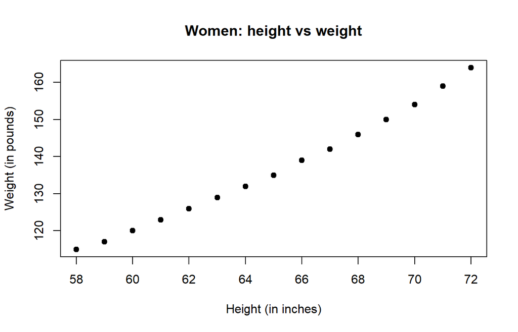

```r
plot(women$height, women$weight,
     xlab = "Height (in inches)", ylab = "Weight (in pounds)",
     main = "Women: height vs weight", pch = 19)
```

The points go up almost in a straight line. Now I fit the model with `lm(y ~ x, data)`:

```r
fit1 <- lm(weight ~ height, data = women)
summary(fit1)
```

```
##
## Call:
## lm(formula = weight ~ height, data = women)
##
## Residuals:
##     Min      1Q  Median      3Q     Max
## -1.7333 -1.1333 -0.3833  0.7417  3.1167
##
## Coefficients:
##              Estimate Std. Error t value Pr(>|t|)
## (Intercept) -87.51667    5.93694  -14.74 1.71e-09 ***
## height        3.45000    0.09114   37.85 1.09e-14 ***
## ---
## Signif. codes:  0 '***' 0.001 '**' 0.01 '*' 0.05 '.' 0.1 ' ' 1
##
## Residual standard error: 1.525 on 13 degrees of freedom
## Multiple R-squared:  0.991,  Adjusted R-squared:  0.9903
## F-statistic:  1433 on 1 and 13 DF,  p-value: 1.091e-14
```

**How I interpret this:**

- **Intercept (about -87.5):** the predicted weight at height 0. This number has no real meaning here because nobody has zero height. It just anchors the line.
- **Slope for height (about 3.45):** for every extra inch of height, weight goes up by about 3.45 pounds on average.
- **p-value of the slope:** it is extremely small, so height is clearly related to weight in this data.
- **R-squared (about 0.99):** height alone explains roughly 99% of the variation in weight.

Adding the fitted line to the plot:

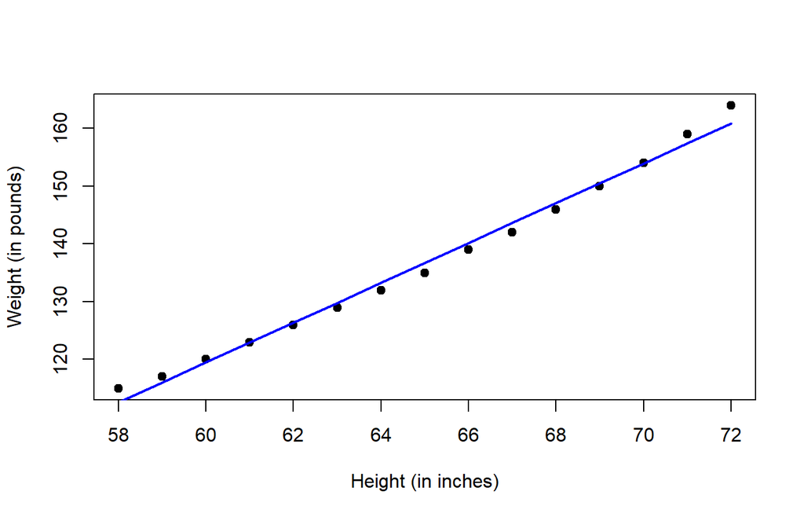

```r
plot(women$height, women$weight,
     xlab = "Height (in inches)", ylab = "Weight (in pounds)", pch = 19)
lines(women$height, fitted(fit1), col = "blue", lwd = 2)
```

The line looks good, but if I look closely, the points curve a little away from it at both ends. That makes me curious about a curved model.

## 2. Polynomial regression: adding a squared term

I add `height^2` with `I()`, which tells R to treat it as a real square and not as formula syntax.

```r
fit2 <- lm(weight ~ height + I(height^2), data = women)
summary(fit2)
```

```
##
## Call:
## lm(formula = weight ~ height + I(height^2), data = women)
##
## Residuals:
##      Min       1Q   Median       3Q      Max
## -0.50941 -0.29611 -0.00941  0.28615  0.59706
##
## Coefficients:
##              Estimate Std. Error t value Pr(>|t|)
## (Intercept) 261.87818   25.19677  10.393 2.36e-07 ***
## height       -7.34832    0.77769  -9.449 6.58e-07 ***
## I(height^2)   0.08306    0.00598  13.891 9.32e-09 ***
## ---
## Signif. codes:  0 '***' 0.001 '**' 0.01 '*' 0.05 '.' 0.1 ' ' 1
##
## Residual standard error: 0.3841 on 12 degrees of freedom
## Multiple R-squared:  0.9995, Adjusted R-squared:  0.9994
## F-statistic: 1.139e+04 on 2 and 12 DF,  p-value: < 2.2e-16
```

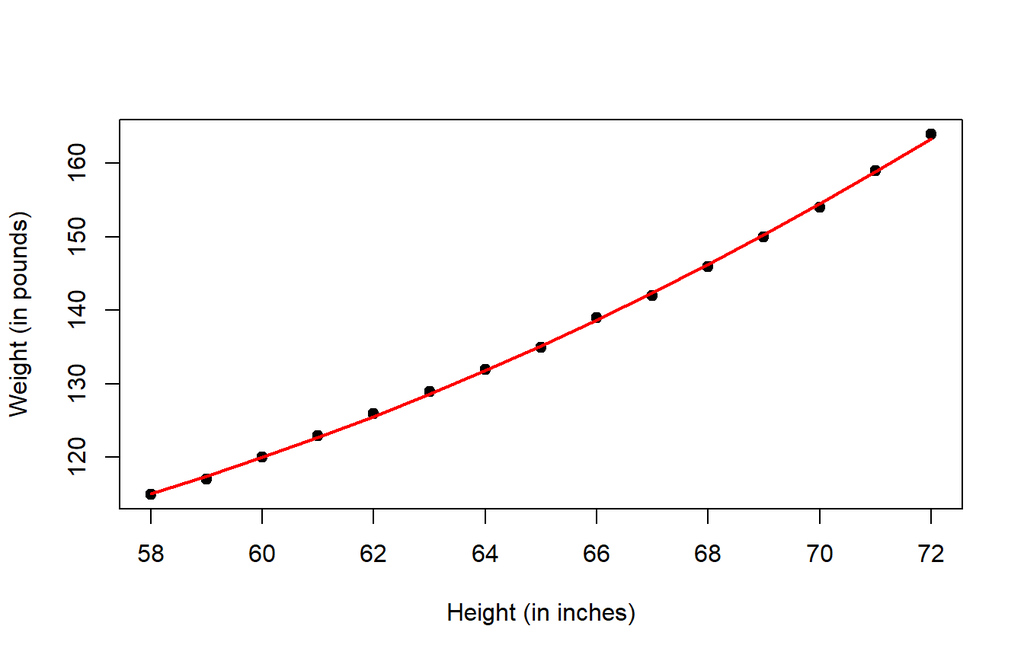

```r
plot(women$height, women$weight,
     xlab = "Height (in inches)", ylab = "Weight (in pounds)", pch = 19)
lines(women$height, fitted(fit2), col = "red", lwd = 2)
```

Comparing the two models:

```r
anova(fit1, fit2)
```

```
## Analysis of Variance Table
##
## Model 1: weight ~ height
## Model 2: weight ~ height + I(height^2)
##   Res.Df     RSS Df Sum of Sq      F    Pr(>F)
## 1     13 30.2333
## 2     12  1.7701  1    28.463 192.96 9.322e-09 ***
## ---
## Signif. codes:  0 '***' 0.001 '**' 0.01 '*' 0.05 '.' 0.1 ' ' 1
```

```r
c(AIC_linear = AIC(fit1), AIC_quadratic = AIC(fit2))
```

```
##    AIC_linear AIC_quadratic
##      59.08158      18.51270
```

**How I interpret this:** the squared term is significant, R-squared goes up a bit, and the AIC is lower for the quadratic model (lower is better). So the curve fits better. The `anova()` test points the same way. The catch is that the straight line was already very good, so the improvement is small. In practice I would also think about whether a curve makes sense for the real-world story, not only the numbers.

## 3. Multiple linear regression (homework)

> HW: Find a data set on which you can fit multiple linear regression and interpret your results.

I chose `mtcars`. The question is: **what drives a car’s fuel efficiency (`mpg`)?** My predictors are weight (`wt`), horsepower (`hp`) and number of cylinders (`cyl`, which I turn into a factor since it is really a category).

```r
cars <- mtcars
cars$cyl <- factor(cars$cyl)
str(cars[, c("mpg", "wt", "hp", "cyl")])
```

```
## 'data.frame':    32 obs. of  4 variables:
##  $ mpg: num  21 21 22.8 21.4 18.7 18.1 14.3 24.4 22.8 19.2 ...
##  $ wt : num  2.62 2.88 2.32 3.21 3.44 ...
##  $ hp : num  110 110 93 110 175 105 245 62 95 123 ...
##  $ cyl: Factor w/ 3 levels "4","6","8": 2 2 1 2 3 2 3 1 1 2 ...
```

A quick look at how the numeric variables relate to each other:

```r
round(cor(mtcars[, c("mpg", "wt", "hp")]), 2)
```

```
##       mpg    wt    hp
## mpg  1.00 -0.87 -0.78
## wt  -0.87  1.00  0.66
## hp  -0.78  0.66  1.00
```

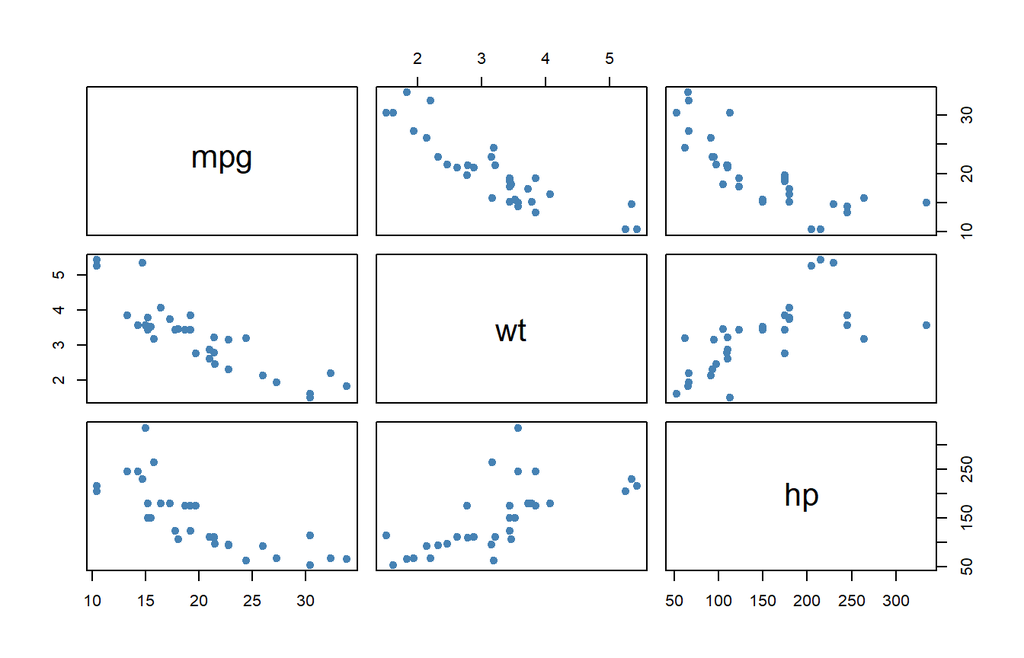

```r
pairs(mtcars[, c("mpg", "wt", "hp")], pch = 19, col = "steelblue")
```

`wt` and `hp` are positively correlated with each other (heavier cars tend to be stronger), and both are negatively correlated with `mpg`. That is worth remembering, since predictors that overlap can make coefficients harder to interpret.

I start with the two numeric predictors:

```r
fit3 <- lm(mpg ~ wt + hp, data = cars)
summary(fit3)
```

```
##
## Call:
## lm(formula = mpg ~ wt + hp, data = cars)
##
## Residuals:
##    Min     1Q Median     3Q    Max
## -3.941 -1.600 -0.182  1.050  5.854
##
## Coefficients:
##             Estimate Std. Error t value Pr(>|t|)
## (Intercept) 37.22727    1.59879  23.285  < 2e-16 ***
## wt          -3.87783    0.63273  -6.129 1.12e-06 ***
## hp          -0.03177    0.00903  -3.519  0.00145 **
## ---
## Signif. codes:  0 '***' 0.001 '**' 0.01 '*' 0.05 '.' 0.1 ' ' 1
##
## Residual standard error: 2.593 on 29 degrees of freedom
## Multiple R-squared:  0.8268, Adjusted R-squared:  0.8148
## F-statistic: 69.21 on 2 and 29 DF,  p-value: 9.109e-12
```

**How I interpret this:**

- **Intercept (about 37.2):** the predicted mpg for a car with `wt = 0` and `hp = 0`. Not realistic, but it is the baseline of the equation.
- **wt (about -3.88):** holding horsepower constant, each extra 1000 lbs of weight lowers mpg by about 3.9.
- **hp (about -0.032):** holding weight constant, each extra horsepower lowers mpg by about 0.03.
- **R-squared (about 0.83):** the two variables together explain roughly 83% of the variation in mpg.
- The phrase **“holding the other variables constant”** is the key difference from simple regression, because each coefficient is the effect of one variable with the others fixed.

Now I add the cylinder factor to see if it helps:

```r
fit4 <- lm(mpg ~ wt + hp + cyl, data = cars)
summary(fit4)
```

```
##
## Call:
## lm(formula = mpg ~ wt + hp + cyl, data = cars)
##
## Residuals:
##     Min      1Q  Median      3Q     Max
## -4.2612 -1.0320 -0.3210  0.9281  5.3947
##
## Coefficients:
##             Estimate Std. Error t value Pr(>|t|)
## (Intercept) 35.84600    2.04102  17.563 2.67e-16 ***
## wt          -3.18140    0.71960  -4.421 0.000144 ***
## hp          -0.02312    0.01195  -1.934 0.063613 .
## cyl6        -3.35902    1.40167  -2.396 0.023747 *
## cyl8        -3.18588    2.17048  -1.468 0.153705
## ---
## Signif. codes:  0 '***' 0.001 '**' 0.01 '*' 0.05 '.' 0.1 ' ' 1
##
## Residual standard error: 2.44 on 27 degrees of freedom
## Multiple R-squared:  0.8572, Adjusted R-squared:  0.8361
## F-statistic: 40.53 on 4 and 27 DF,  p-value: 4.869e-11
```

```r
anova(fit3, fit4)
```

```
## Analysis of Variance Table
##
## Model 1: mpg ~ wt + hp
## Model 2: mpg ~ wt + hp + cyl
##   Res.Df    RSS Df Sum of Sq      F  Pr(>F)
## 1     29 195.05
## 2     27 160.78  2     34.27 2.8776 0.07364 .
## ---
## Signif. codes:  0 '***' 0.001 '**' 0.01 '*' 0.05 '.' 0.1 ' ' 1
```

For a factor, R picks the first level (4 cylinders) as the reference, and the `cyl6` and `cyl8` rows are the differences compared with 4-cylinder cars. When I compare the two models with `anova()`, I look at the p-value to decide whether adding `cyl` improves the fit enough to keep it. If the p-value is large, the simpler model `fit3` is the better choice, since a simpler model that works equally well is easier to explain.

A prediction from the model: a car weighing 3000 lbs (`wt = 3`) with 120 hp.

```r
predict(fit3, newdata = data.frame(wt = 3, hp = 120),
        interval = "prediction")
```

```
##        fit      lwr      upr
## 1 21.78102 16.38174 27.18031
```

The output gives a predicted mpg plus a range in which a new car like that would likely fall.

## 4. Regression diagnostics

A model can have a great R-squared and still be unreliable if its assumptions are broken. Linear regression assumes:

1. The relationship is **linear**.
2. The residuals are **normally distributed**.
3. The residuals have **constant variance** (homoscedasticity).
4. The observations are **independent**, and there are no overly influential points.

I check these for `fit3`. The `plot()` function on a model gives four diagnostic plots at once:

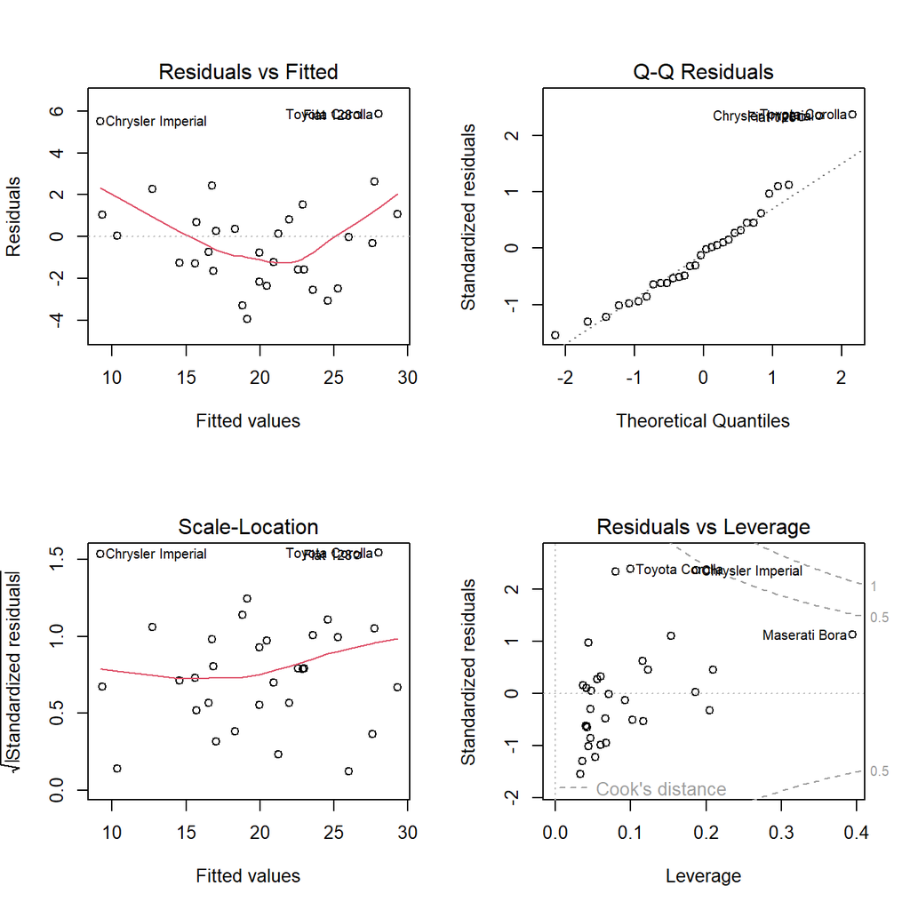

```r
par(mfrow = c(2, 2))
plot(fit3)
```

```r
par(mfrow = c(1, 1))
```

**How I read each plot:**

- **Residuals vs Fitted:** I want a flat, patternless cloud around zero. A clear curve would suggest the relationship is not linear.
- **Normal Q-Q:** I want the points to follow the dashed diagonal. Large departures at the ends mean the residuals are not normal.
- **Scale-Location:** I want an even spread. A funnel shape would mean the variance changes (heteroscedasticity).
- **Residuals vs Leverage:** this finds points with a large influence on the fit. Points outside the Cook’s distance lines deserve a closer look.

Some numbers to go with the pictures:

```r
shapiro.test(residuals(fit3))        # normality of residuals
```

```
##
##  Shapiro-Wilk normality test
##
## data:  residuals(fit3)
## W = 0.92792, p-value = 0.03427
```

```r
# Which observations are most influential?
cooks <- cooks.distance(fit3)
head(sort(cooks, decreasing = TRUE), 3)
```

```
## Chrysler Imperial     Maserati Bora    Toyota Corolla
##         0.4236109         0.2720397         0.2083933
```

The Shapiro-Wilk test has the null hypothesis that the residuals are normal, so a p-value above 0.05 means I have no evidence against normality. For Cook’s distance, a common rule of thumb is to look closer at anything above about `4/n`:

```r
n <- nrow(cars)
names(cooks)[cooks > 4 / n]
```

```
## [1] "Chrysler Imperial" "Fiat 128"          "Toyota Corolla"
## [4] "Maserati Bora"
```

**My conclusion:** the model is a decent description of the data, but the diagnostic plots in `mtcars` show a slight curve in the residuals and a few influential cars. So I would trust the overall message (heavier and more powerful cars use more fuel) more than the exact coefficient values. As a possible improvement, I could try a transformation such as `log(mpg)` or add a squared weight term, the same idea I used with the `women` data.

I can also run the same check on the earlier `women` models:

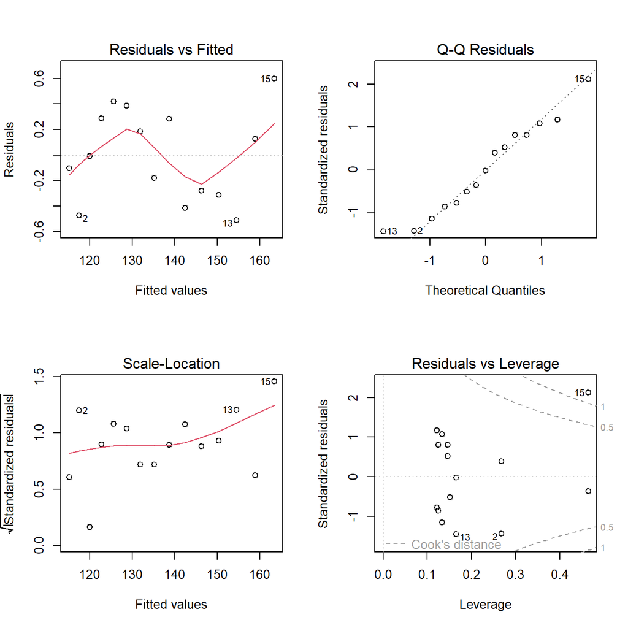

```r
par(mfrow = c(2, 2))
plot(fit2)
```

```r
par(mfrow = c(1, 1))
```

## What I learned

- `lm(y ~ x1 + x2, data)` is the core tool, and `summary()` is where I read the story: coefficients, p-values and R-squared.
- In multiple regression, each coefficient means “the effect of this variable while the others stay the same”.
- A higher R-squared does not automatically mean a better model. I compare models with `anova()` and AIC, and I prefer the simpler one when they perform about the same.
- Diagnostics are not optional. Plotting the residuals tells me whether I can trust the model at all.